# AI_App_Assignment

## Introduction

**Project title:** `Brazilian E-Commerce Data Analysis`

**Student name:** Deepak Sindhu

**Module:** M504A AI and Applications

**Student Id:** GH1056312

### 1. Business Context

**Client:** Olist, an online company that connects small businesses with consumers across the country.

**Dataset:** From 2016 to 2018, approximately one lakh orders were placed and available in this dataset. Order, customer, product, seller, payment, shipping and customer review details are all included.

**Why a data scientist is needed:**  
Olist wants to understand its sales performance and customer satisfaction. This will help the company make better decisions about inventory, managing sellers, shipping and marketing. They need a clear analysis of their past performance.

**Objective of this project:**  
I am working as a data analyst with Shvintech LLP and my responsibility is to clean, analyse and explore the data, answer important business questions and provide suggestions to the client, Olist.

**Data Name:** Brazilian E-Commerce Public Dataset by Olist

**Dataset URL:** https://www.kaggle.com/datasets/olistbr/brazilian-ecommerce

**Github Repo** https://github.com/deepak324/e_commerce/tree/final_complex

## 2. Dataset Exploration

The dataset is distributed across several related CSV files. The main tables used are orders, customers, order items, products, sellers, payments, reviews and product-category translation.

```python
import pandas as pd
import numpy as np
import matplotlib.pyplot as plot
import seaborn as sns
from scipy import stats

customers = pd.read_csv("olist_customers_dataset.csv")
orders = pd.read_csv("olist_orders_dataset.csv")
items = pd.read_csv("olist_order_items_dataset.csv")
products = pd.read_csv("olist_products_dataset.csv")
sellers = pd.read_csv("olist_sellers_dataset.csv")
payments = pd.read_csv("olist_order_payments_dataset.csv")
reviews = pd.read_csv("olist_order_reviews_dataset.csv")
translation = pd.read_csv("product_category_name_translation.csv")

print("Order_shape:", orders.shape)
print("Customers_shape:", customers.shape)
print("Items_shape:", items.shape)
print("Products_shape:", products.shape)
print("Sellers_shape:", sellers.shape)
print("Payments_shape:", payments.shape)
print("Reviews_shape:", reviews.shape)
```

```
Order_shape: (99441, 8)
Customers_shape: (99441, 5)
Items_shape: (112650, 7)
Products_shape: (32951, 9)
Sellers_shape: (3095, 4)
Payments_shape: (103886, 5)
Reviews_shape: (99224, 7)
```

**Interpretation:** The tables are related to each other rather than independent. Therefore, to join these table, requires correct keys such as order_id, customer_id, product_id and seller_id.

```python
# Checking missing_values values and duplicates

tables = {
    "customers": customers,
    "orders": orders,
    "items": items,
    "products": products,
    "sellers": sellers,
    "payments": payments,
    "reviews": reviews,
    "translation": translation
}

for name, table in tables.items():
    missing_values = table.isna().sum()
    missing_values = missing_values[missing_values > 0]
    print(f"\n {name.upper()} ({table.shape[0]:,} rows × {table.shape[1]} columns)")
    if len(missing_values) == 0:
        print("No missing_values present")
    else:
        print(missing_values.to_string())
        print(f"Total missing_values: {table.isna().sum().sum():,}")

for name, table in tables.items():
    n_duplicates_row = table.duplicated().sum()
    print(f"{name:12} → {n_duplicates_row:,} duplicate rows")

# duplicate checks on primary and business keys
key_checks = {
    "customers": "customer_id",
    "orders": "order_id",
    "items": ["order_id", "order_item_id"],
    "products": "product_id",
    "sellers": "seller_id",
    "payments": ["order_id", "payment_sequential"],
    "reviews": "review_id",
    "translation": "product_category_name"
}

for name, key in key_checks.items():
    n_dup_key_check = tables[name].duplicated(subset=key).sum()
    print(f"{name:12} (key: {key}) → {n_dup_key_check:,} duplicate key(s)")
```

```
 CUSTOMERS (99,441 rows × 5 columns)
No missing_values present

 ORDERS (99,441 rows × 8 columns)
order_approved_at                 160
order_delivered_carrier_date     1783
order_delivered_customer_date    2965
Total missing_values: 4,908

 ITEMS (112,650 rows × 7 columns)
No missing_values present

 PRODUCTS (32,951 rows × 9 columns)
product_category_name         610
product_name_lenght           610
product_description_lenght    610
product_photos_qty            610
product_weight_g                2
product_length_cm               2
product_height_cm               2
product_width_cm                2
Total missing_values: 2,448

 SELLERS (3,095 rows × 4 columns)
No missing_values present

 PAYMENTS (103,886 rows × 5 columns)
No missing_values present

 REVIEWS (99,224 rows × 7 columns)
review_comment_title      87656
review_comment_message    58247
Total missing_values: 145,903

 TRANSLATION (71 rows × 2 columns)
No missing_values present
customers    → 0 duplicate rows
orders       → 0 duplicate rows
items        → 0 duplicate rows
products     → 0 duplicate rows
sellers      → 0 duplicate rows
payments     → 0 duplicate rows
reviews      → 0 duplicate rows
translation  → 0 duplicate rows
customers    (key: customer_id) → 0 duplicate key(s)
orders       (key: order_id) → 0 duplicate key(s)
items        (key: ['order_id', 'order_item_id']) → 0 duplicate key(s)
products     (key: product_id) → 0 duplicate key(s)
sellers      (key: seller_id) → 0 duplicate key(s)
payments     (key: ['order_id', 'payment_sequential']) → 0 duplicate key(s)
reviews      (key: review_id) → 814 duplicate key(s)
translation  (key: product_category_name) → 0 duplicate key(s)
```

**Interpretation:** The dataset is generally clean. missing values mainly appear in order delivery timestamps (expected for non-delivered orders) and a small number of product attributes. Almost all tables have unique keys. 814 duplicate review ID are the only quality issue. These should be removed prior to analysis to avoid inflating customer satisfaction metrics.

```python
# removing duplicate reviews

print(" before removing duplicates review table shape:", reviews.shape)
print("Duplicate review_id count:", reviews.duplicated(subset="review_id").sum())
reviews = reviews.drop_duplicates(subset="review_id", keep="first")

# Keep only the first instance of each review_id
review = reviews[["order_id","review_score"]].drop_duplicates("order_id")
```

```
 before removing duplicates review table shape: (99224, 7)
Duplicate review_id count: 814
```

**Interpretation** Only the first instance of each duplicate review id was kept, removing 814 duplicate review records. This helps to prevent that review is only counted once, improving the accuracy and reliability of customer satisfaction analyses later.

```python
orders.info()
orders.isna().sum().sort_values(ascending=False).head(10)
orders["order_status"].value_counts()
```

```
<class 'pandas.core.frame.DataFrame'>
RangeIndex: 99441 entries, 0 to 99440
Data columns (total 8 columns):
 #   Column                         Non-Null Count  Dtype
---  ------                         --------------  -----
 0   order_id                       99441 non-null  object
 1   customer_id                    99441 non-null  object
 2   order_status                   99441 non-null  object
 3   order_purchase_timestamp       99441 non-null  object
 4   order_approved_at              99281 non-null  object
 5   order_delivered_carrier_date   97658 non-null  object
 6   order_delivered_customer_date  96476 non-null  object
 7   order_estimated_delivery_date  99441 non-null  object
dtypes: object(8)
memory usage: 6.1+ MB
```

```
order_status
delivered      96478
shipped         1107
canceled         625
unavailable      609
invoiced         314
processing       301
created            5
approved           2
Name: count, dtype: int64
```

**Interpretation:** The order table contains several timestamps that shows different stages of the order lifecycle. missing delivery dates need to be considered carefully because not every order reached the delivered stage

## 3. Data Preprocessing and Feature Engineering

Convert the order dates into datetime format.

```python
date_columns_val = [ "order_purchase_timestamp", "order_approved_at", "order_delivered_carrier_date", "order_delivered_customer_date", "order_estimated_delivery_date" ]
for value in date_columns_val: orders[value] = pd.to_datetime(orders[value], errors="coerce")
```

The product-category translation is added so that product categories can be interpreted in English.

```python
products = products.merge( translation, on="product_category_name", how="left" )

products["category"] = products["product_category_name_english"].fillna( products["product_category_name"] )
```

For the main analysis, delivered orders are used for delivery-performance questions because actual delivery time cannot be calculated reliably for orders that were not delivered.

```python
delivered_order = orders[orders["order_status"]=="delivered"].copy()
delivered_order = delivered_order.dropna(
    subset=["order_delivered_customer_date", "order_estimated_delivery_date"]
)
delivered_order["delivery_days"] = ( delivered_order["order_delivered_customer_date"] - delivered_order["order_purchase_timestamp"] ).dt.total_seconds()/86400
delivered_order["delay_days"] = ( delivered_order["order_delivered_customer_date"] - delivered_order["order_estimated_delivery_date"] ).dt.total_seconds()/86400
delivered_order["late"] = delivered_order["delay_days"] > 0
```

```python
# Creating analytical order-item dataset.
data_df = items.merge( delivered_order[["order_id","customer_id","order_purchase_timestamp", "order_delivered_customer_date", "order_estimated_delivery_date","delivery_days","late"]], on="order_id", how="inner" )
data_df = data_df.merge( customers[["customer_id","customer_state"]], on="customer_id", how="left" )
data_df = data_df.merge( products[["product_id","category"]], on="product_id", how="left" )
data_df = data_df.merge( sellers[["seller_id","seller_state"]], on="seller_id", how="left" )
data_df["revenue"] = data_df["price"] + data_df["freight_value"]
data_df["month"] = data_df["order_purchase_timestamp"].dt.to_period("M").astype(str)
print(data_df.shape)
print(data_df.isna().sum().sort_values(ascending=False).head())
```

```
(110189, 18)
category         1537
order_id            0
order_item_id       0
revenue             0
seller_state        0
dtype: int64
```

## 4. Explanatory Data Analysis

## Business Question 4.1 — Which product categories generate the highest sales value?

**Business importance** This can support inventory, promotion and category-management decisions.

```
category
health_beauty            1258681.34
watches_gifts            1205005.68
bed_bath_table           1036988.68
sports_leisure            988048.97
computers_accessories     911954.32
furniture_decor           729762.49
cool_stuff                635290.85
housewares                632248.66
auto                      592720.11
garden_tools              485256.46
Name: price, dtype: float64
```

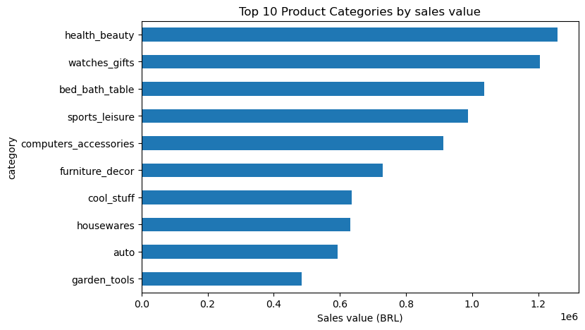

```python
# Dataset for sales analysis – includes all order statuses
sales_df = items.merge(
    orders[["order_id", "customer_id", "order_purchase_timestamp", "order_status"]],
    on="order_id",
    how="inner"
)

# Add English category
sales_df = sales_df.merge(
    products[["product_id", "category"]],
    on="product_id",
    how="left"
)

sales_df["category"] = sales_df["category"].fillna("Unknown")

# Top 10 categories by sale value
sales_value = (
    sales_df.groupby("category")["price"]
    .sum()
    .sort_values(ascending=False)
    .head(10)
)

print(sales_value)

sales_value.sort_values().plot(kind="barh", figsize=(8,5))
plot.title("Top 10 Product Categories by sales value")
plot.xlabel("Sales value (BRL)")
plot.show()
```

**Interpretation** The results showed that health and beauty had highest sale value of approximate 1.26M BRL followed by watches and gifts with value 1.21M BRL and bed and bath table value 1.04M BRL.

## Business Question 4.2 — How did sales change over time for delivered orders?

**Business importance** This analysis will help to identify periods of higher or lower sales and can support decisions about marketing, inventory planning and promotions.

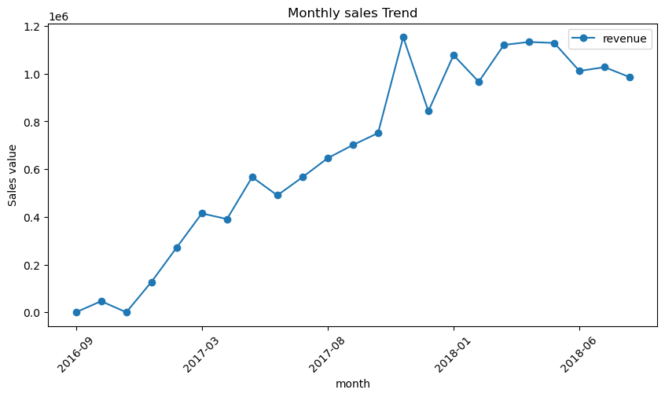

```python
monthly_purchase = ( data_df.groupby("month") .agg(revenue=("revenue","sum"), orders=("order_id","nunique")) .reset_index() )
monthly_purchase.plot(x="month",y="revenue",figsize=(10,5),marker="o")
plot.xticks(rotation=45)
plot.title("Monthly sales Trend")
plot.ylabel("Sales value")
plot.show()
```

**Interpretation** Peaks values indicate stronger purchasing periods, while weaker months may require promotional or marketing attention. The observed pattern cannot be treated as permanent pattern or future rule, it is just for the time period of the data we have.

## Business Question 4.3 — Which states generate the most revenue?

**Business importance** Geographic analysis helps the business to find its strongest markets and see where most of sales is happening.

```
                   revenue  orders
customer_state
SP              5768518.23   40494
RJ              2055401.57   12350
MG              1818891.67   11354
RS               861278.79    5344
PR               781708.80    4923
SC               595127.78    3546
BA               591137.81    3256
DF               346123.35    2080
GO               334212.35    1957
ES               317657.93    1995
```

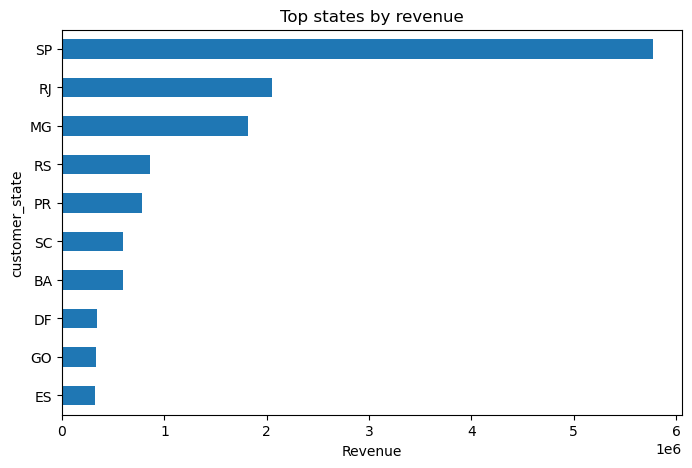

```python
state_wise_sales_data = ( data_df.groupby("customer_state") .agg(revenue=("revenue","sum"), orders=("order_id","nunique")) .sort_values("revenue",ascending=False) .head(10) )
print(state_wise_sales_data)
state_wise_sales_data["revenue"].sort_values().plot( kind="barh",figsize=(8,5) )
plot.title("Top states by revenue")
plot.xlabel("Revenue")
plot.show()
```

**Interpretation** The results show that Sao Paulo provides the highest revenue, followed by Rio de Janeiro and Minas Gerais. The result suggests that Olist may have opportunities to expand sales in lower-performing areas, while strong markets could receive targeted retention and promotional activity.

## Business Question 4.4 — Does delivery performance affect customer satisfaction?

**Business importance** Late delivery can affect negatively the customer satisfaction. Understanding the relationship between delivery performance and reviews, management can improve logistics services.

```python
delivery_review_status = delivered_order[ ["order_id","delivery_days","late"] ].merge(review,on="order_id",how="inner")
print( delivery_review_status.groupby("late")["review_score"] .agg(["count","mean"]) )
```

```
       count      mean
late
False  87751  4.296156
True    7613  2.565874
```

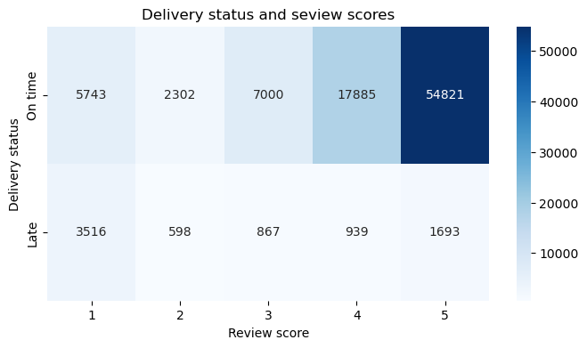

```python
heatmap_data = pd.crosstab(
    delivery_review_status["late"],
    delivery_review_status["review_score"]
)

# Rename delivery status
heatmap_data.index = ["On time", "Late"]

# Draw heatmap
plot.figure(figsize=(8, 4))

sns.heatmap(
    heatmap_data,
    annot=True,
    fmt="d",
    cmap="Blues"
)

plot.title("Delivery status and seview scores")
plot.xlabel("Review score")
plot.ylabel("Delivery status")
plot.show()
```

**Interpretation** The results indicate that late orders have a much lower average review score (2.57) than on-time orders (4.30). Late orders have a substantially lower score, delivery reliability should be treated as an important customer-experience priority.

This does not prove that late delivery is the only cause of customer dissatisfaction because other factors, such as product quality and seller performance, also influence reviews.

### Business Question 4.5 — Which sellers combine high revenue with strong customer satisfaction?

**Business importance** Seller performance is important because Olist operates as a marketplace. Identifying sellers that generate substantial revenue while maintaining good customer ratings can help management understand successful marketplace behaviour.

```python
seller_rev_df = ( data_df.groupby("seller_id") .agg(revenue=("revenue","sum"), orders=("order_id","nunique")) )
seller_review = (
    data_df[["order_id", "seller_id"]]
    .drop_duplicates()
    .merge(review, on="order_id", how="inner")
    .groupby("seller_id")["review_score"]
    .mean()
)
performance_of_seller = seller_rev_df.join(seller_review,how="inner")
top_sellers_val = performance_of_seller[ (performance_of_seller["orders"]>=20) & (performance_of_seller["review_score"]>=4) ].sort_values("revenue",ascending=False).head(10)
print(top_sellers_val)
```

```
                                    revenue  orders  review_score
seller_id
4869f7a5dfa277a7dca6462dcf3b52b2  247007.06    1124      4.149013
53243585a1d6dc2643021fd1853d8905  230797.02     348      4.193642
fa1c13f2614d7b5c4749cbc52fecda94  200833.50     578      4.372822
da8622b14eb17ae2831f4ac5b9dab84a  184706.78    1311      4.183515
7e93a43ef30c4f03f38b393420bc753a  171973.55     319      4.364780
1025f0e2d44d7041d6cf58b6550e0bfa  171924.96     910      4.011161
7a67c85e85bb2ce8582c35f2203ad736  160278.52    1145      4.276165
955fee9216a65b617aa5c0531780ce60  156606.48    1261      4.200479
1f50f920176fa81dab994f9023523100  141712.94    1399      4.141109
46dc3b2cc0980fb8ec44634e21d2718e  134162.88     503      4.273642
```

**Interpretation** The filter reduces the influence of sellers with very few orders. Sellers satisfying both conditions generate meaningful revenue and maintain strong average review scores. These sellers can provide useful examples of effective marketplace performance.

### Business Question 4.6 —Which product categories are associated with the lowest customer review scores?

**Business importance** Revenue alone does not provide a complete picture of product performance. Categories with poor customer satisfaction may require investigation into product quality, seller behaviour, descriptions or delivery.

```python
# Creating unique order-category combination
category_review_by_order = (
    data_df[["order_id", "category"]]
    .drop_duplicates()
    .merge(
        review,
        on="order_id",
        how="inner"
    )
)

# calculating review score through category
cat_review_df = (
    category_review_by_order
    .groupby("category")
    .agg(
        reviews=("review_score", "count"),
        score=("review_score", "mean")
    )
    .sort_values("score")
)

cat_review_df
```

| category | reviews | score |
| --- | --- | --- |
| security_and_services | 2 | 2.500000 |
| pc_gamer | 7 | 3.428571 |
| portateis_cozinha_e_preparadores_de_alimentos | 13 | 3.615385 |
| office_furniture | 1237 | 3.644301 |
| fashion_male_clothing | 104 | 3.817308 |
| ... | ... | ... |
| books_imported | 50 | 4.440000 |
| food_drink | 218 | 4.444954 |
| books_general_interest | 491 | 4.533605 |
| cds_dvds_musicals | 12 | 4.666667 |
| fashion_childrens_clothes | 7 | 5.000000 |

73 rows × 2 columns

```python
cat_review_filtered = cat_review_df[cat_review_df["reviews"] >= 50]

print(cat_review_filtered.head(10))
```

```
                           reviews     score
category
office_furniture              1237  3.644301
fashion_male_clothing          104  3.817308
audio                          345  3.840580
home_confort                   389  3.902314
fixed_telephony                209  3.966507
construction_tools_safety      158  3.974684
home_construction              478  3.985356
fashion_underwear_beach        114  3.991228
bed_bath_table                9078  4.003966
telephony                     4064  4.052165
```

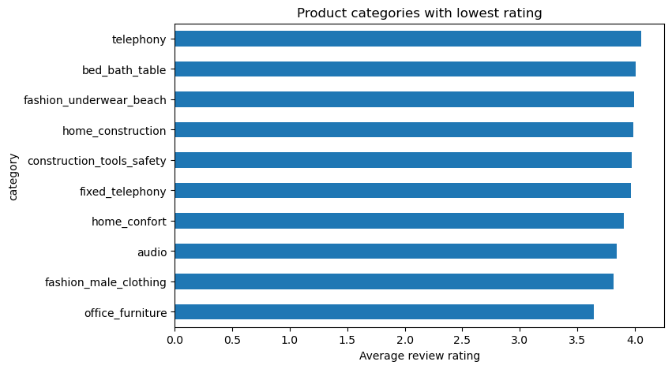

```python
cat_review_filtered.head(10)["score"].sort_values().plot(
    kind="barh",
    figsize=(8,5)
)

plot.title("Product categories with lowest rating")
plot.xlabel("Average review rating")
plot.show()
```

**Interpretation** Based only on products with at least 50 reviews, Office furniture get lower ratings than other categories These are just patterns in the data, they do not prove why the scores are lower. More research is required to understand the cause.

### Business Question 4.7 — Are expensive freight costs associated with lower customer satisfaction?

**Business importance** Freight is a significant part of the customer purchase experience. The value of high shipping costs might affect perceived value and customer satisfaction.

```python
# calculating total freight cost for every order
order_freight = (
    data_df.groupby("order_id", as_index=False)["freight_value"]
    .sum()
)

# merge total freight cost with customers review score
freight_review_df = (
    order_freight
    .merge(review[["order_id", "review_score"]], on="order_id", how="inner")
    .drop_duplicates("order_id")
)

# divided orders into four freight group
freight_bins_val = pd.qcut(
    freight_review_df["freight_value"],
    q=4,
    duplicates="drop"
)

# comparing average review scores
freight_review_summary_val = (
    freight_review_df
    .groupby(freight_bins_val, observed=True)["review_score"]
    .mean()
)

print(freight_review_summary_val)
```

```
freight_value
(-0.001, 13.84]     4.315889
(13.84, 17.17]      4.194037
(17.17, 23.99]      4.178145
(23.99, 1794.96]    3.943876
Name: review_score, dtype: float64
```

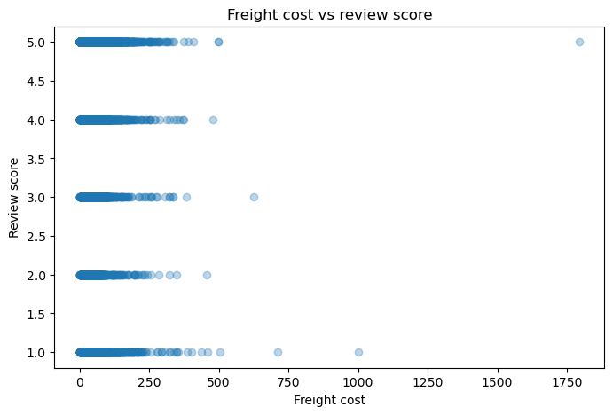

```python
plot.figure(figsize=(8, 5))

plot.scatter(
    freight_review_df["freight_value"],
    freight_review_df["review_score"],
    alpha=0.3
)

plot.xlabel("Freight cost")
plot.ylabel("Review score")
plot.title("Freight cost vs review score")

plot.show()
```

## 5. Overall Findings

The analysis demonstrates how Olist's relational data can be combined to investigate sales, customers, products, sellers and logistics.

The strongest business insights should be taken from the actual outputs generated by the notebook. Particular attention should be given to:

- Highest-sales-value product categories;
- Monthly sales patterns;
- Strongest customer states;
- Delivery performance and customer review scores;
- High-performing sellers;
- Low-rated product categories; and
- The relationship between freight cost and customer satisfaction.

The analysis also demonstrates that business performance cannot be evaluated using sales value alone. Customer satisfaction, delivery performance, seller performance and freight cost provide additional dimensions for evaluating marketplace performance.

All these findings can help the client company in identifying strong areas, improve customer experience and support better business decisions.

## 6. Business Recommendations

**Focus on categories that are doing well** The company should continue to provide its products in categories that generate a good amount of sales value and run focused promotions.

**Enhance delivery reliability**

The analysis shows that lower review scores associated with late delivery, hence logistics performance should be prioritized. The company should monitor late delivery rates by seller and location.

**Look out for low-rated categories** In categories where review scores remain low, product quality, seller performance, descriptions and delivery issues should all be investigated.

**Give rewards to successful sellers** High sales - value sellers with high customer ratings could be benchmarked against marketplace best practices.

**Check out regional opportunities** Potential expansion opportunities would be areas with lower sales value but marketing investment should be supported by further analysis of the customer, logistics and purchasing behavior.

## 7. Limitations

This analysis has several limitations.

First, the dataset covers a historical period from 2016 to 2018, so the findings should not automatically be generalised to the current e-commerce market.

Second, the analysis is explanatory rather than causal. Relationships between delivery, freight, reviews and sales do not prove that one variable directly causes another.

Third, some orders do not have complete delivery information. Therefore, delivery-time analysis focuses on delivered orders.

Finally, customer review scores are subjective and may not capture every aspect of customer experience.

## 8. Conclusion

In this research, the Olist Brazilian e-commerce dataset was analyzed in an explanatory way using Python and Pandas. An analytical dataset was created by cleaning and merging several relevant datasets.

The seven business questions studied were in the areas of sales, time, location, logistics, sellers, freight costs, product categories and customer satisfaction.

The analysis shows how data-driven techniques can turn transactional data into business insights. The most important managerial insight is that market performance should be judged by multiple measures, not sales value alone. The sales data, combined with consumer input, delivery performance,freight costs and seller behavior provides a more complete picture of the business.

## References

Olist (n.d.) *Brazilian E-Commerce Public Dataset by Olist*. Kaggle. Available at: https://www.kaggle.com/datasets/olistbr/brazilian-ecommerce (Accessed: 11 September 2026).